# Practical Machine Learning Final Project

Jeremias T. Lalis

December 20, 2016

## Introduction

Using devices such as Jawbone Up, Nike FuelBand, and Fitbit it is now possible to collect a large amount of data about personal activity relatively inexpensively. These type of devices are part of the quantified self movement - a group of enthusiasts who take measurements about themselves regularly to improve their health, to find patterns in their behaviour, or because they are tech geeks.

One thing that people regularly do is quantify how much of a particular activity they do, but they rarely quantify how well they do it. In this project, your goal will be to use data from accelerometers on the belt, forearm, arm, and dumbell of 6 participants. They were asked to perform barbell lifts correctly and incorrectly in 5 different ways. More information is available from the website here: http://groupware.les.inf.puc-rio.br/har (see the section on the Weight Lifting Exercise Dataset).

## Data

The training data for this project are available here: https://d396qusza40orc.cloudfront.net/predmachlearn/pml-training.csv

The test data are available here: https://d396qusza40orc.cloudfront.net/predmachlearn/pml-testing.csv

## Method

### Data Preprocessing

The data was cleaned from any variables that mostly consists of “NA” or blank fields:

```r
library(caret)
training <- read.csv('pml-training.csv')

nums <- sapply(training, is.numeric)
training_num <- training[ , nums]
training_num <- training_num[ , apply(training_num, 2,
             function(x) !any(is.na(x)))]
training_num$class <- training$class
```

The training data was split into training ant test sets - 70% vs 30%:

```r
set.seed(123)
samp <- sample(2, nrow(training), replace = TRUE,
                  prob = c(0.7,0.3))
trainSet_num <- training_num[samp == 1,]
testSet_num  <- training_num[samp == 2,]
```

All numeric variables were standardized in the training set using the preProcess() finction in caret:

```r
preObj <- preProcess(trainSet_num[,1:56],
                        method=c("center","scale"))
trainSet_st <- predict(preObj, trainSet_num[,1:56])
trainSet_st$class <- trainSet_num$class
```

The test set was standardized using the parameters obtained by standardizing the training set:

```r
testSet_st <- predict(preObj, testSet_num[,1:56])
testSet_st$class <- testSet_num$class
```

### Model Building

#### Decision Tree - rpart

- Decision Tree model - decision tree using rpart with caret
- Predictors were obtained from a PCA on the numeric variables that captures 80% of the variance

```r
library(rpart)
library(rattle)
pca <- preProcess(trainSet_st[,1:56], method = "pca",
                     thresh = 0.8)
trainPC <- predict(pca, trainSet_st[,1:56])

set.seed(123)
modelFit <- train(trainSet_st$class ~., method = "rpart",
                     data = trainPC)
modelFit$finalModel
```

```
## n= 13808
##
## node), split, n, loss, yval, (yprob)
##       * denotes terminal node
##
##  1) root 13808 9892 A (0.28 0.2 0.17 0.17 0.18)
##    2) PC13< 0.6625947 11363 7814 A (0.31 0.23 0.2 0.16 0.1)
##      4) PC8>=0.6673183 3636 1740 A (0.52 0.2 0.16 0.048 0.066) *
##      5) PC8< 0.6673183 7727 5881 B (0.21 0.24 0.22 0.21 0.12)
##       10) PC9< -0.7422318 2054 1094 B (0.23 0.47 0.065 0.098 0.14) *
##       11) PC9>=-0.7422318 5673 4129 C (0.21 0.16 0.27 0.25 0.12)
##         22) PC13< -0.6561928 1629  870 A (0.47 0.26 0.12 0.11 0.042) *
##         23) PC13>=-0.6561928 4044 2695 C (0.1 0.11 0.33 0.3 0.15) *
##    3) PC13>=0.6625947 2445 1101 E (0.15 0.047 0.045 0.21 0.55) *
```

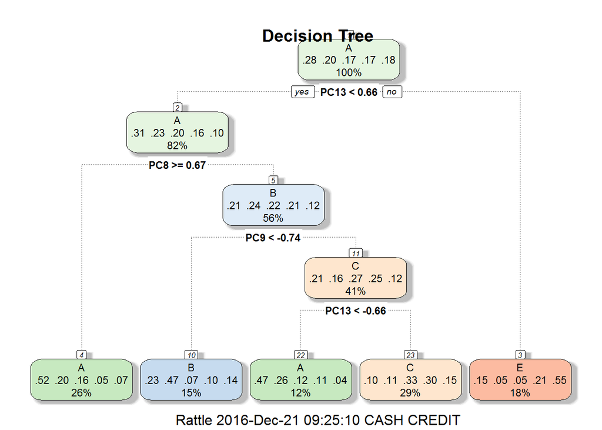

```r
fancyRpartPlot(modelFit$finalModel, main="Decision Tree")
```

```r
trainPred <- predict(modelFit, trainPC)
confusionMatrix(trainPred, trainSet_num$class)
```

```
## Confusion Matrix and Statistics
##
##           Reference
## Prediction    A    B    C    D    E
##          A 2655 1162  785  355  308
##          B  479  960  134  201  280
##          C  415  461 1349 1214  605
##          D    0    0    0    0    0
##          E  367  114  111  509 1344
##
## Overall Statistics
##
##                Accuracy : 0.4568
##                  95% CI : (0.4485, 0.4652)
##     No Information Rate : 0.2836
##     P-Value [Acc > NIR] : < 2.2e-16
##
##                   Kappa : 0.3035
##  Mcnemar's Test P-Value : < 2.2e-16
##
## Statistics by Class:
##
##                      Class: A Class: B Class: C Class: D Class: E
## Sensitivity            0.6780  0.35595   0.5670    0.000  0.52976
## Specificity            0.7362  0.90154   0.7642    1.000  0.90232
## Pos Pred Value         0.5043  0.46738   0.3336      NaN  0.54969
## Neg Pred Value         0.8524  0.85222   0.8945    0.835  0.89501
## Prevalence             0.2836  0.19532   0.1723    0.165  0.18373
## Detection Rate         0.1923  0.06952   0.0977    0.000  0.09733
## Detection Prevalence   0.3813  0.14875   0.2929    0.000  0.17707
## Balanced Accuracy      0.7071  0.62875   0.6656    0.500  0.71604
```

```r
testPC <- predict(pca, testSet_st[,1:56])
prediction <- predict(modelFit, testPC)
confusionMatrix(testSet_num$class, prediction)
```

```
## Confusion Matrix and Statistics
##
##           Reference
## Prediction    A    B    C    D    E
##          A 1099  215  183    0  167
##          B  489  384  184    0   43
##          C  328   60  605    0   50
##          D  153  101  495    0  188
##          E  132  121  247    0  570
##
## Overall Statistics
##
##                Accuracy : 0.4572
##                  95% CI : (0.4443, 0.4701)
##     No Information Rate : 0.3786
##     P-Value [Acc > NIR] : < 2.2e-16
##
##                   Kappa : 0.3022
##  Mcnemar's Test P-Value : < 2.2e-16
##
## Statistics by Class:
##
##                      Class: A Class: B Class: C Class: D Class: E
## Sensitivity            0.4993  0.43587   0.3530       NA  0.55992
## Specificity            0.8436  0.85486   0.8932   0.8388  0.89575
## Pos Pred Value         0.6605  0.34909   0.5801       NA  0.53271
## Neg Pred Value         0.7345  0.89457   0.7676       NA  0.90556
## Prevalence             0.3786  0.15153   0.2948   0.0000  0.17509
## Detection Rate         0.1890  0.06605   0.1041   0.0000  0.09804
## Detection Prevalence   0.2862  0.18920   0.1794   0.1612  0.18404
## Balanced Accuracy      0.6715  0.64536   0.6231       NA  0.72783
```

```r
model_summary <- data.frame("model" = character(3), "accuracy" = numeric(3))
model_summary$model <- as.character(model_summary$model)
model_summary$model[1] <- "DT"
model_summary$accuracy[1] <- round(confusionMatrix(testSet_num$class, prediction)$overall[[1]], 2)
```

#### Support Vector Machine - 5-fold Cross Validation

- Predictors are obtained from a PCA on the numeric variables with 5 components
- trainControl() function set to 5-fold cross validation

```r
## PCA with 5 components
pca_svm <- preProcess(trainSet_st[,1:56],
                         method = "pca", pcaComp = 5)
trainPC_svm <- predict(pca_svm, trainSet_st[,1:56])

## Setting up trainControl() function
tc = trainControl(method = "cv", number = 5)

## Training process
set.seed(825)
svmFit <- train(trainSet_st$class ~ ., data = trainPC_svm,
                method = "svmRadial", trControl = tc)
svmFit$finalModel
```

```
## Support Vector Machine object of class "ksvm"
##
## SV type: C-svc  (classification)
##  parameter : cost C = 1
##
## Gaussian Radial Basis kernel function.
##  Hyperparameter : sigma =  0.302566999788478
##
## Number of Support Vectors : 10927
##
## Objective Function Value : -2906.406 -3386.514 -2400.228 -2029.506 -2877.132 -2446.867 -2644.118 -2388.594 -2146.149 -2217.424
## Training error : 0.379563
```

```r
## Predicting on test data
testPC_svm <- predict(pca_svm, testSet_st[,1:56])
prediction_svm <- predict(svmFit, testPC_svm)

## Correct predictions
predRight_svm <- prediction_svm == testSet_st$class

## Confusion Matrix on the test set
confusionMatrix(prediction_svm, testSet_st$class)
```

```
## Confusion Matrix and Statistics
##
##           Reference
## Prediction    A    B    C    D    E
##          A 1223  189  288   95   82
##          B   82  577  106   69   98
##          C  135   93  428  108   71
##          D  189  129  180  609  141
##          E   35  112   41   56  678
##
## Overall Statistics
##
##                Accuracy : 0.6046
##                  95% CI : (0.5919, 0.6172)
##     No Information Rate : 0.2862
##     P-Value [Acc > NIR] : < 2.2e-16
##
##                   Kappa : 0.498
##  Mcnemar's Test P-Value : < 2.2e-16
##
## Statistics by Class:
##
##                      Class: A Class: B Class: C Class: D Class: E
## Sensitivity            0.7350  0.52455  0.41035   0.6499   0.6336
## Specificity            0.8424  0.92469  0.91469   0.8690   0.9486
## Pos Pred Value         0.6516  0.61910  0.51257   0.4880   0.7354
## Neg Pred Value         0.8880  0.89287  0.87648   0.9282   0.9199
## Prevalence             0.2862  0.18920  0.17939   0.1612   0.1840
## Detection Rate         0.2104  0.09924  0.07362   0.1047   0.1166
## Detection Prevalence   0.3228  0.16030  0.14362   0.2147   0.1586
## Balanced Accuracy      0.7887  0.72462  0.66252   0.7595   0.7911
```

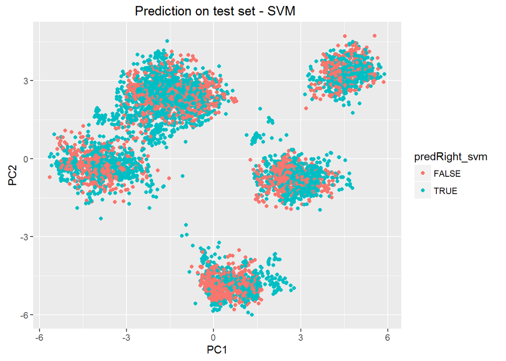

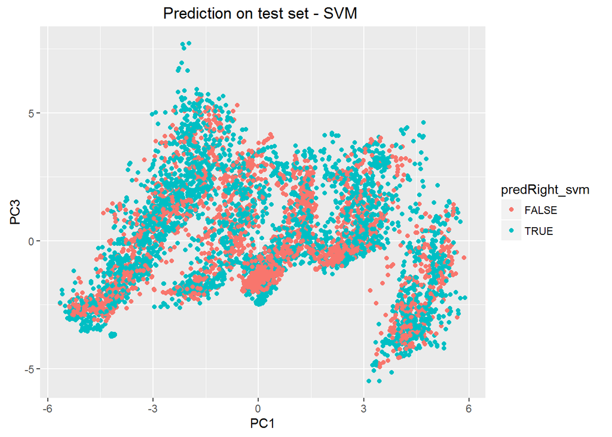

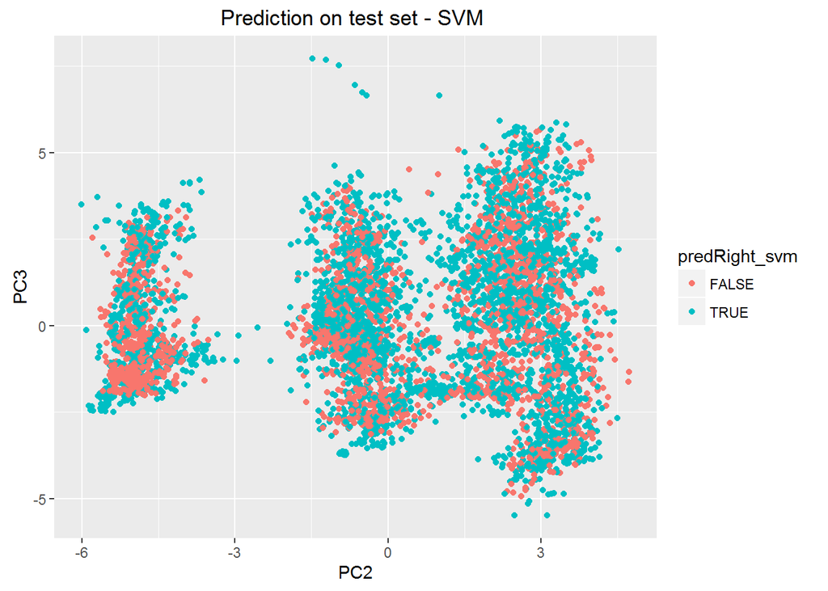

```r
model_summary$model[2] <- "SVM"
model_summary$accuracy[2] <- round(confusionMatrix(prediction_svm, testSet_st$class)$overall[[1]], 2)

## Plots
plotSVM <- qplot(PC1, PC2, data = testPC_svm, colour = predRight_svm, main = "Prediction on test set - SVM " )


plotSVM2 <- qplot(PC1, PC3, data = testPC_svm, colour = predRight_svm, main = "Prediction on test set - SVM " )
plotSVM3 <- qplot(PC2, PC3, data = testPC_svm, colour = predRight_svm, main = "Prediction on test set - SVM " )
plotSVM ; plotSVM2 ; plotSVM3
```

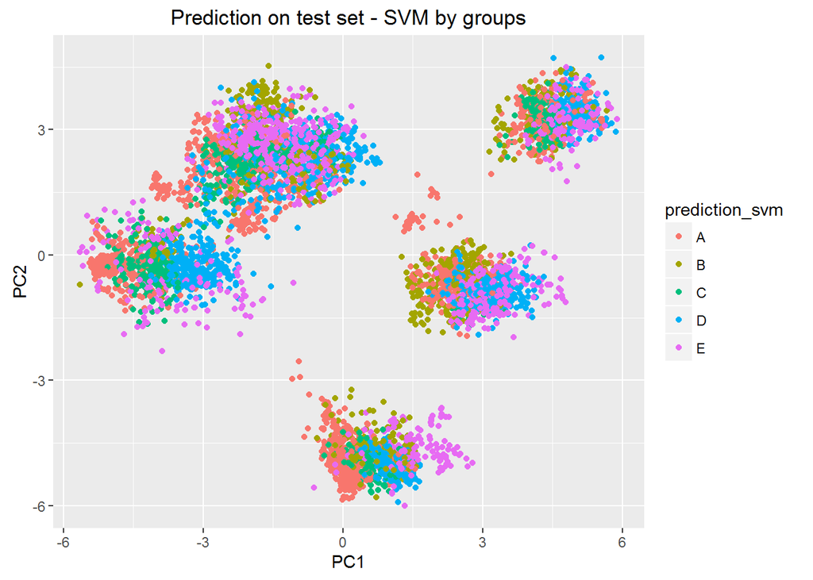

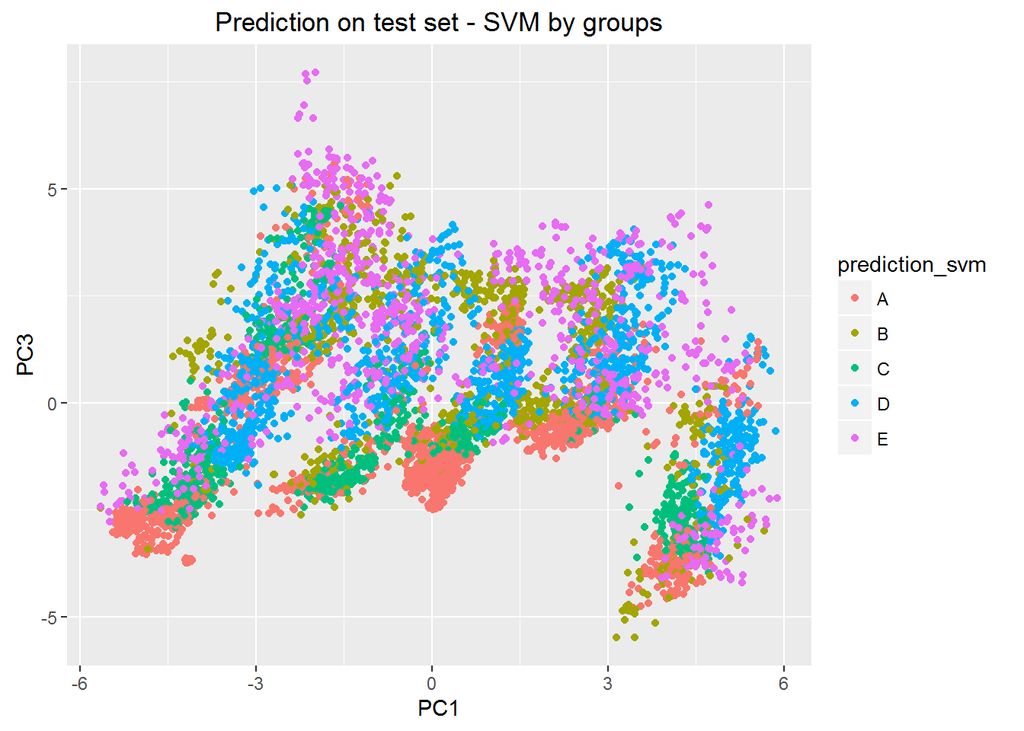

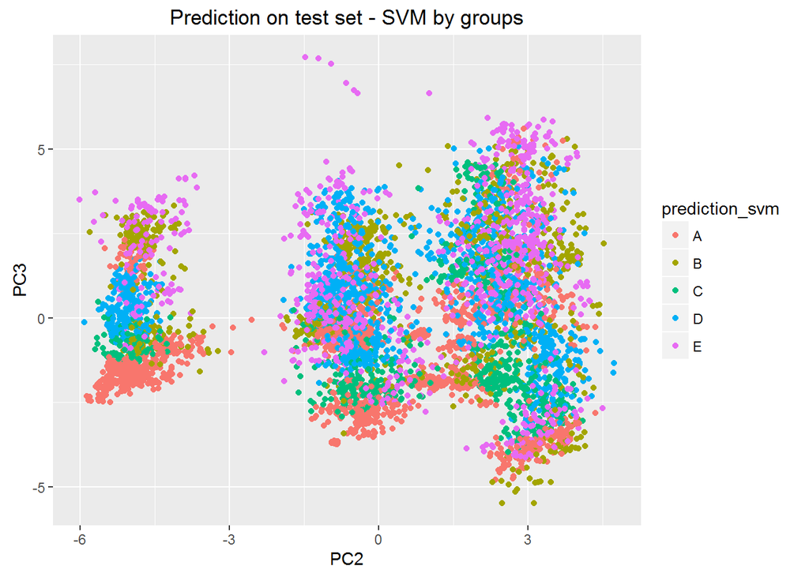

```r
plotSVM_pred <- qplot(PC1, PC2, data = testPC_svm, colour = prediction_svm, main = "Prediction on test set - SVM by groups" )
plotSVM_pred2 <- qplot(PC1, PC3, data = testPC_svm, colour = prediction_svm, main = "Prediction on test set - SVM by groups" )
plotSVM_pred3 <- qplot(PC2, PC3, data = testPC_svm, colour = prediction_svm, main = "Prediction on test set - SVM by groups" )
plotSVM_pred ; plotSVM_pred2; plotSVM_pred3
```

```r
library(randomForest)
## PCA
pca_rf2 <- preProcess(trainSet_st[,1:56],
                         method = "pca", pcaComp = 5)
trainPC_rf2 <- predict(pca_rf2, trainSet_st[,1:56])

## Setting up trainControl() function
tc = trainControl(method = "cv", number = 5)

# 5-fold cross validation

##Training process
set.seed(17)
modelFit_rf2 <- train(trainSet_st$class ~ .,
                         method = "rf",
                         trainControl = tc,
                         data = trainPC_rf2)
modelFit_rf2$finalModel
```

```
##
## Call:
##  randomForest(x = x, y = y, mtry = param$mtry, trainControl = ..1)
##                Type of random forest: classification
##                      Number of trees: 500
## No. of variables tried at each split: 2
##
##         OOB estimate of  error rate: 14.55%
## Confusion matrix:
##      A    B    C    D    E class.error
## A 3552   98  125   94   47  0.09295199
## B  175 2165  152   97  108  0.19725621
## C  112  127 1975  112   53  0.16981925
## D   87   53  146 1933   60  0.15182097
## E   67  111   95   90 2174  0.14308238
```

```r
## Prediction on the test set
testPC_rf2 <- predict(pca_rf2, testSet_st[,1:56])
prediction_rf2 <- predict(modelFit_rf2, testPC_rf2)

## Correct classifications
predRight_rf2 <- prediction_rf2 == testSet_st$class

## ConfusionMatrix on the test set
confusionMatrix(prediction_rf2, testSet_st$class)
```

```
## Confusion Matrix and Statistics
##
##           Reference
## Prediction    A    B    C    D    E
##          A 1498   61   43   44   31
##          B   35  918   58   14   39
##          C   68   58  873   88   42
##          D   42   43   49  768   28
##          E   21   20   20   23  930
##
## Overall Statistics
##
##                Accuracy : 0.8578
##                  95% CI : (0.8485, 0.8666)
##     No Information Rate : 0.2862
##     P-Value [Acc > NIR] : < 2.2e-16
##
##                   Kappa : 0.82
##  Mcnemar's Test P-Value : 3.277e-08
##
## Statistics by Class:
##
##                      Class: A Class: B Class: C Class: D Class: E
## Sensitivity            0.9002   0.8345   0.8370   0.8196   0.8692
## Specificity            0.9569   0.9690   0.9463   0.9668   0.9823
## Pos Pred Value         0.8933   0.8628   0.7733   0.8258   0.9172
## Neg Pred Value         0.9599   0.9617   0.9637   0.9654   0.9708
## Prevalence             0.2862   0.1892   0.1794   0.1612   0.1840
## Detection Rate         0.2577   0.1579   0.1502   0.1321   0.1600
## Detection Prevalence   0.2884   0.1830   0.1942   0.1600   0.1744
## Balanced Accuracy      0.9286   0.9018   0.8917   0.8932   0.9257
```

```r
model_summary$model[3] <- "RF"
model_summary$accuracy[3] <- round(confusionMatrix(prediction_rf2, testSet_st$class)$overall[[1]], 2)
```

### Selection of Best Model

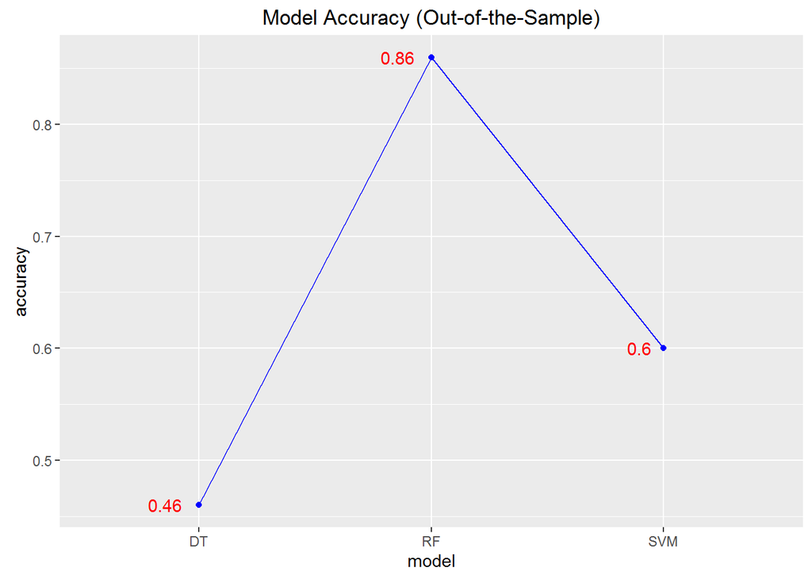

```r
library(ggplot2)
p <- ggplot(model_summary, aes(x=model, y=accuracy, group = 1)) +
      geom_line(colour = "blue") +
      geom_point(colour = "blue") +
      geom_text(aes(label = accuracy), hjust = 1.5, vjust = .5, colour = "red") +
      ggtitle("Model Accuracy (Out-of-the-Sample)")

print(p)
```

Figure above shows that the RF model with five (5) principal components shows the best predictive power at 86%, followed by Support Vector Machine-model and Decision Tree-model at 60% and 46%, respectively.